# Concrete Strength Prediction Case Study.

# Contents:

- . Context:
- 1. Importing Libraries
- 1. Reading and Review of the dataset.
- 1. EDA Discriptive Observations
- 1. Transposing index and columns
- 1. Checking for error, duplicates and missing vales
- 1. MultiVariate Analysis
- 1. Univariate analysis.
- 1. Bi-variate analysis.
- 1. K-Means Clustering.
- 1. Checking for correlation
- 1. Get Data Ready & Building Model using Sklearn Library.
- 1. Featuring Engineering and Model Building.
- 1. Applying Ensemble Learning Techniques.
- 1. Random Forest
- 1. Gradient Boosting Regressor.
- 1. AdaBoost Regressor.
- 1. KNN Regressor.
- 1. Bagging Regressor.
- 1. Support Vector Regressor.
- 1. XBoost Regressor.
- 1. Decision Tree Regressor.
- 1. Linear Regression, Lasso & Ridge.
- 1. Lasso.
- 1. RIGDE.
- 1. RandomizedSearchCV_GridSearchCV.
- 1. Conclusion.
- 1. References & GitHub Link.

# Context:

# Project Problem Statement - FMST

**Problem Statement: Concrete Strength Prediction**

**Objective**

To predict the concrete strength using the data available in file "concrete.csv". Apply feature engineering and model tuning to obtain 85% to 95% accuracy.

**Resources Available**

The data for this project is available in file https://archive.ics.uci.edu/ml/machine-learning-databases/concrete/compressive/. The same has been shared along with the course content.

**Steps and Tasks:**

Exploratory Data Quality Report Reflecting the Following: Univariate analysis –data types and description of the independent attributes which should include (name, range of values observed, central values (mean and median), standard deviation and quartiles, analysis of the body of distributions/tails, missing values, outliers, duplicates(10 Marks) Bi-variate analysis between the predictor variables and between the predictor variables and target column. Comment on your findings in terms of their relationship and degree of relation if any. Visualize the analysis using boxplots and pair plots, histograms, or density curves. (10 marks) Feature Engineering techniques(10 marks) Identify opportunities (if any) to extract new features from existing features, drop a feature(if required) Get the data model ready and do a train test split. Decide on the complexity of the model, should it be a simple linear model in terms of parameters or would a quadratic or higher degree.

Creating the Model and Tuning It: Algorithms that you think will be suitable for this project. Use Kfold Cross-Validation to evaluate model performance. Use appropriate metrics and make a DataFrame to compare models w.r.t their metrics. (at least 3 algorithms, one bagging and one boosting based algorithms have to be there). (15 marks) Techniques employed to squeeze that extra performance out of the model without making it overfit. Use Grid Search or Random Search on any of the two models used above. Make a DataFrame to compare models after hyperparameter tuning and their metrics as above. (15 marks)

**Attribute Information:**

Given are the variable name, variable type, the measurement unit, and a brief description. The concrete compressive strength is the regression problem. The order of this listing corresponds to the order of numerals along the rows of the database.

Name Data Type Measurement Description

1. Cement (cement) quantitative kg in a m3 mixture Input Variable
2. Blast Furnace Slag (slag) quantitative kg in a m3 mixture Input Variable
3. Fly Ash (ash) quantitative kg in a m3 mixture Input Variable
4. Water(water) quantitative kg in a m3 mixture Input Variable
5. Superplasticizer (superplastic) quantitative kg in a m3 mixture Input Variable
6. Coarse Aggregate (coarseagg) quantitative kg in a m3 mixture Input Variable
7. Fine Aggregate (fineagg) quantitative kg in a m3 mixture Input Variable
8. Age(age) quantitative Day (1~365) Input Variable
9. Concrete compressive strength(strength) quantitative MPa Output Variable

# Taskes

- Importing the Libraries.
- Reading & review of the dataset.
- Exploratory Data abalysis.
  - IQR and outliers analysis.
  - Distribution of independent variables.
  - vistualization with pair plots.
  - checking correlation with heatmap.
  - Checking for error, duplicates and missing vales.
- K-means clustring.
- zscore.
- Data spliting train_test
- Model Building.
- Scaling
- Model Evaluation

# Importing Libraries

```python
# The following line of code to import laibraries.
import pandas as pd
import numpy as np
import matplotlib.pyplot as plt
%matplotlib inline
# To enable plotting graphs in Jupyter notebook
import seaborn as sns
import warnings
warnings.filterwarnings('ignore')

# Remove scientific notations and display numbers with 2 decimal points instead
pd.options.display.float_format = '{:,.2f}'.format
```

# Reading and Review of the dataset.

```python
#Load the file from local directory using pd.read_csv which is a special form of read_table
concrete_df = pd.read_csv("concrete.csv").copy()
df = concrete_df.copy()
df.head()
```

|  | cement | slag | ash | water | superplastic | coarseagg | fineagg | age | strength |
| --- | --- | --- | --- | --- | --- | --- | --- | --- | --- |
| 0 | 141.30 | 212.00 | 0.00 | 203.50 | 0.00 | 971.80 | 748.50 | 28 | 29.89 |
| 1 | 168.90 | 42.20 | 124.30 | 158.30 | 10.80 | 1,080.80 | 796.20 | 14 | 23.51 |
| 2 | 250.00 | 0.00 | 95.70 | 187.40 | 5.50 | 956.90 | 861.20 | 28 | 29.22 |
| 3 | 266.00 | 114.00 | 0.00 | 228.00 | 0.00 | 932.00 | 670.00 | 28 | 45.85 |
| 4 | 154.80 | 183.40 | 0.00 | 193.30 | 9.10 | 1,047.40 | 696.70 | 28 | 18.29 |

```python
missing_value = ['na', '?', 'n/a', '-', '--',  '/', '???']
df = pd.read_csv('concrete.csv', na_values= missing_value).copy()
```

```python
# The following line of code to view dataset columns.
df.columns
```

```
Index(['cement', 'slag', 'ash', 'water', 'superplastic', 'coarseagg',
       'fineagg', 'age', 'strength'],
      dtype='object')
```

```python
# The following line of code to view dataset shape.
df.shape
```

```
(1030, 9)
```

```python
# The following line of code to view dataset info.
df.info()
```

```
<class 'pandas.core.frame.DataFrame'>
RangeIndex: 1030 entries, 0 to 1029
Data columns (total 9 columns):
 #   Column        Non-Null Count  Dtype
---  ------        --------------  -----
 0   cement        1030 non-null   float64
 1   slag          1030 non-null   float64
 2   ash           1030 non-null   float64
 3   water         1030 non-null   float64
 4   superplastic  1030 non-null   float64
 5   coarseagg     1030 non-null   float64
 6   fineagg       1030 non-null   float64
 7   age           1030 non-null   int64
 8   strength      1030 non-null   float64
dtypes: float64(8), int64(1)
memory usage: 72.5 KB
```

```python
# The following line of code to view the dataset data types.
df.dtypes
```

```
cement          float64
slag            float64
ash             float64
water           float64
superplastic    float64
coarseagg       float64
fineagg         float64
age               int64
strength        float64
dtype: object
```

```python
# The following line of code to view dataset unique values.
df.nunique()
```

```
cement          278
slag            185
ash             156
water           195
superplastic    111
coarseagg       284
fineagg         302
age              14
strength        845
dtype: int64
```

# EDA Discriptive Observations.

```python
# Printing dataset columns for numerical values.
df.describe()
```

|  | cement | slag | ash | water | superplastic | coarseagg | fineagg | age | strength |
| --- | --- | --- | --- | --- | --- | --- | --- | --- | --- |
| count | 1,030.00 | 1,030.00 | 1,030.00 | 1,030.00 | 1,030.00 | 1,030.00 | 1,030.00 | 1,030.00 | 1,030.00 |
| mean | 281.17 | 73.90 | 54.19 | 181.57 | 6.20 | 972.92 | 773.58 | 45.66 | 35.82 |
| std | 104.51 | 86.28 | 64.00 | 21.35 | 5.97 | 77.75 | 80.18 | 63.17 | 16.71 |
| min | 102.00 | 0.00 | 0.00 | 121.80 | 0.00 | 801.00 | 594.00 | 1.00 | 2.33 |
| 25% | 192.38 | 0.00 | 0.00 | 164.90 | 0.00 | 932.00 | 730.95 | 7.00 | 23.71 |
| 50% | 272.90 | 22.00 | 0.00 | 185.00 | 6.40 | 968.00 | 779.50 | 28.00 | 34.45 |
| 75% | 350.00 | 142.95 | 118.30 | 192.00 | 10.20 | 1,029.40 | 824.00 | 56.00 | 46.14 |
| max | 540.00 | 359.40 | 200.10 | 247.00 | 32.20 | 1,145.00 | 992.60 | 365.00 | 82.60 |

## Observation

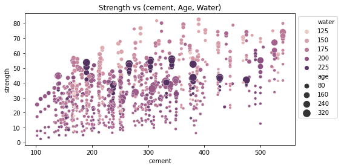

```python
# The following line of code to plot the correlation between cement,age & water with strength.
fig, ax = plt.subplots(figsize=(8,4))
sns.scatterplot(y='strength', x='cement', hue='water', size='age', data=df, ax=ax, sizes=(20,150))
ax.set_title('Strength vs (cement, Age, Water)')
ax.legend(loc='upper left', bbox_to_anchor=(1,1))
plt.show()
```

# Observation.

- The older the cement is more water it requires.
- Concrete strength increases with less water are used in preparing it.
- cement with low age requires more cement for higher strength.
- Compression strength increases with the amount of cement.
- compressive strength increases with age.

```python
# The following code line to print the df mean.
df.mean()
```

```
cement         281.17
slag            73.90
ash             54.19
water          181.57
superplastic     6.20
coarseagg      972.92
fineagg        773.58
age             45.66
strength        35.82
dtype: float64
```

```python
# The following code line to print the df median.
df.median()
```

```
cement         272.90
slag            22.00
ash              0.00
water          185.00
superplastic     6.40
coarseagg      968.00
fineagg        779.50
age             28.00
strength        34.45
dtype: float64
```

```python
# The following code line to print the df std.
df.std()
```

```
cement         104.51
slag            86.28
ash             64.00
water           21.35
superplastic     5.97
coarseagg       77.75
fineagg         80.18
age             63.17
strength        16.71
dtype: float64
```

```python
# Checking if there are any skewness in the df.
df.skew()
```

```
cement          0.51
slag            0.80
ash             0.54
water           0.07
superplastic    0.91
coarseagg      -0.04
fineagg        -0.25
age             3.27
strength        0.42
dtype: float64
```

# Observation.

- The concrete strength increases depend on the amount of cement applied.
- The concrete strength increases with age.
- The cement with low age require more cement to increase concrete strength.
- The older the cement is the more water requires.
- The concrete strength increases when less water is used in preparing.

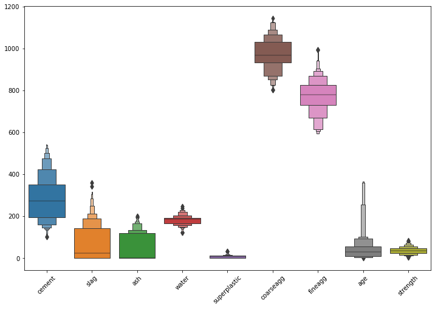

```python
# Following the line of codes to visualize the outliers by using boxplot.
plt.subplots(figsize=(12,8))
ax = sns.boxenplot(data=df)
ax.set_xticklabels(ax.get_xticklabels(), rotation=45);
```

- **Age data appears to have outliers because maximum values are very high as compared to the 3rd IQR value.**

## MultiVariate Analysis

### Visualizing Distribution Of Independent Variables.

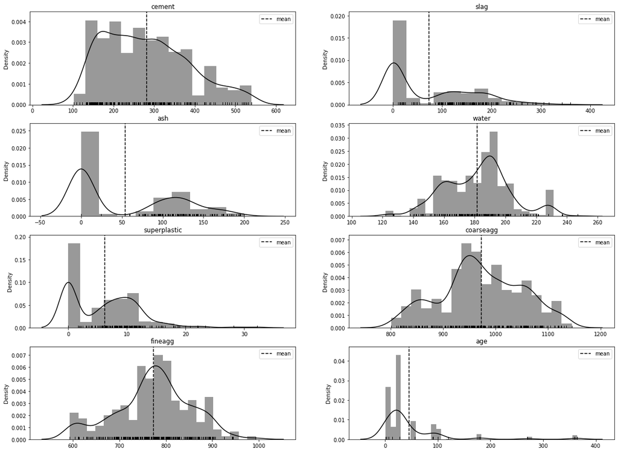

```python
# The following line of codes to visualize the dataset independent variables.
import itertools
cols = [i for i in df.columns if i != 'strength']
fig = plt.figure(figsize=(20,15))
for i,j in itertools.zip_longest(cols, range(len(cols))):
    plt.subplot(4,2,j+1)
    ax = sns.distplot(df[i],color='black',rug=True)
    plt.axvline(df[i].mean(),linestyle="dashed",label="mean", color='black')
    plt.legend()
    plt.title(i)
    plt.xlabel("")
```

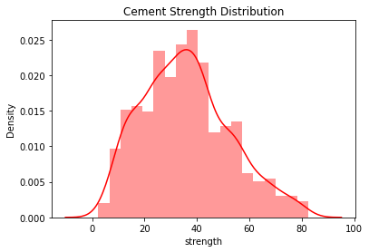

```python
# The following code line to print the df strenth distribution.
ax = sns.distplot(df.strength, color='red')
ax.set_title("Cement Strength Distribution")
```

# Obsavation.

**Diagonal analysis with distplots analysis.**

**Off-diagonal analysis with strength.**

- Cement has a strong correlation with cement.
- Slag is a very weak predictor because of imbalanced distribution.
- Ash, coarseagg, and finding are weak and not reliable predictors.
- Water indicates to have a negative correlation with strength.
- Superplastic indicates to have a positive correlation with strength.
- Age has a strong correlation with strength.

# Identifying Outliers with interquartile Range (IQR)

By calculating the differences between the 75th and 25th percentiles. it is represented by the formula **IQR = Q3 - Q1.** The lines of code below calculate and print the inequalities range for each of the variables in the dataset.

```python
# Calculating the interquartile Range. (IQR)
Q1 = df.quantile(0.25)
Q3 = df.quantile(0.75)
IQR = Q3 - Q1
print(IQR)
```

```
cement         157.62
slag           142.95
ash            118.30
water           27.10
superplastic    10.20
coarseagg       97.40
fineagg         93.05
age             49.00
strength        22.43
dtype: float64
```

### will calculate for the cement.

```python
from scipy import stats
# the following code of line prints the Quartiles.
Q1=df['cement'].quantile(q=0.25)
Q3=df['cement'].quantile(q=0.75)
print('1st Quartile (Q1)is:', Q1)
print('3rd Quartile (Q3)is:', Q3)
print('interquartile range (IQR) is', stats.iqr(df['cement']))
```

```
1st Quartile (Q1)is: 192.375
3rd Quartile (Q3)is: 350.0
interquartile range (IQR) is 157.625
```

### will set a lower & upper limit to detect outliers.

```python
# The following code of line to detect the interquartile range (IQR) is the original.
L_outliers=Q1-1.5*(Q3-Q1)
U_outliers=Q3+1.5*(Q3-Q1)
print('Lower outlier limit in cement', L_outliers )
print('Upper outlier limit in cement', U_outliers)
```

```
Lower outlier limit in cement -44.0625
Upper outlier limit in cement 586.4375
```

```python
# The following code of lines to check the presence of the outliers with the lower & upper limits.
print('Number of the outlier in cement upper : ', df[df['cement']>586.4375]['cement'].count())
print('Number of the outlier in cement Lower : ', df[df['cement']<-44.0625]['cement'].count())
print('% of outlier in cemnet Upper: ',round(df[df['cement']>586.4375]['cement'].count()*100/len(df)),'%')
print('% of outlier in cemnet Lower: ',round(df[df['cement']<-44.0625]['cement'].count()*100/len(df)),'%')
```

```
Number of the outlier in cement upper :  0
Number of the outlier in cement Lower :  0
% of outlier in cemnet Upper:  0 %
% of outlier in cemnet Lower:  0 %
```

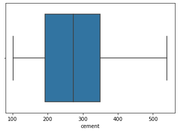

```python
# will check if there are any outliers in the distribution of cement.
sns.boxplot(x='cement', data=df, orient='h')
```

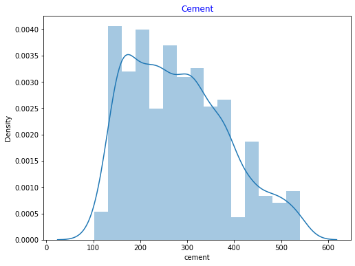

```python
plt.figure(figsize=(8,6))
sns.distplot(df['cement']).set_title('Cement', color='blue')
```

### will calculate for the Water.

```python
# the following code of line prints the Quartiles.
w_Q1=df['water'].quantile(q=0.25)
w_Q3=df['water'].quantile(q=0.75)
print('1st Quartile (Q1)is:', w_Q1)
print('3rd Quartile (Q3)is:', w_Q3)
print('interquartile range (IQR) is', stats.iqr(df['water']))
```

```
1st Quartile (Q1)is: 164.9
3rd Quartile (Q3)is: 192.0
interquartile range (IQR) is 27.099999999999994
```

```python
# The following code of line to detect the interquartile range (IQR) is the original.
WL_outliers=Q1-1.5*(w_Q3-w_Q1)
WU_outliers=Q3+1.5*(w_Q3-w_Q1)
print('Lower outlier limit in water', WL_outliers )
print('Upper outlier limit in water', WU_outliers)
```

```
Lower outlier limit in water 151.72500000000002
Upper outlier limit in water 390.65
```

```python
# The following code of lines to check the presence of the outliers with the lower & upper limits.
print('Number of the outlier in water upper : ', df[df['water']>390.65]['water'].count())
print('Number of the outlier in water Lower : ', df[df['water']<151.72]['water'].count())
print('% of outlier in water Upper: ',round(df[df['water']>390.65]['water'].count()*100/len(df)),'%')
print('% of outlier in water Lower: ',round(df[df['water']<151.72]['water'].count()*100/len(df)),'%')
```

```
Number of the outlier in water upper :  0
Number of the outlier in water Lower :  71
% of outlier in water Upper:  0 %
% of outlier in water Lower:  7 %
```

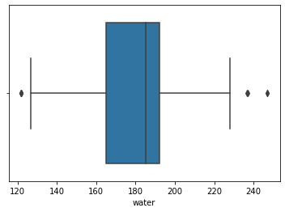

```python
# will check if there are any outliers in the distribution of water.
sns.boxplot(x='water', data=df, orient='h')
```

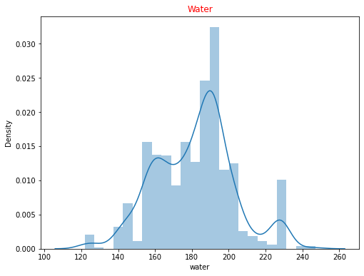

```python
plt.figure(figsize=(8,6))
sns.distplot(df['water']).set_title('Water', color='red')
```

### will calculate for the Slag.

```python
# the following code of line prints the Quartiles.
s_Q1=df['slag'].quantile(q=0.25)
s_Q3=df['slag'].quantile(q=0.75)
print('1st Quartile (Q1)is:', s_Q1)
print('3rd Quartile (Q3)is:', s_Q3)
print('interquartile range (IQR) is', stats.iqr(df['slag']))
```

```
1st Quartile (Q1)is: 0.0
3rd Quartile (Q3)is: 142.95
interquartile range (IQR) is 142.95
```

```python
# The following code of line to detect the interquartile range (IQR) is the original.
SL_outliers=Q1-1.5*(s_Q3-s_Q1)
SU_outliers=Q3+1.5*(s_Q3-s_Q1)
print('Lower outlier limit in slag', SL_outliers )
print('Upper outlier limit in slag', SU_outliers)
```

```
Lower outlier limit in slag -22.049999999999983
Upper outlier limit in slag 564.425
```

```python
# The following code of lines to check the presence of the outliers with the lower & upper limits.
print('Number of the outlier in slag upper : ', df[df['slag']>564.425]['slag'].count())
print('Number of the outlier in slag Lower : ', df[df['slag']<-22.049]['slag'].count())
print('% of outlier in slag   Upper: ',round(df[df['slag']>564.425]['slag'].count()*100/len(df)),'%')
print('% of outlier in slag   Lower: ',round(df[df['slag']<-22.049]['slag'].count()*100/len(df)),'%')
```

```
Number of the outlier in slag upper :  0
Number of the outlier in slag Lower :  0
% of outlier in slag   Upper:  0 %
% of outlier in slag   Lower:  0 %
```

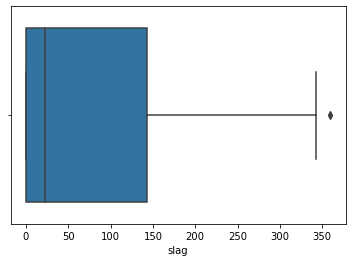

```python
# will check if there are any outliers in the distribution of slag.
sns.boxplot(x='slag', data=df, orient='h')
```

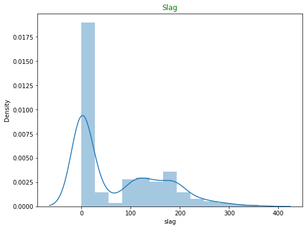

```python
plt.figure(figsize=(8,6))
sns.distplot(df['slag']).set_title('Slag', color='green')
```

### will calculate for the Age.

```python
# the following code of line prints the Quartiles.
Q1=df['age'].quantile(q=0.25)
Q3=df['age'].quantile(q=0.75)
print('1st Quartile (Q1)is:', Q1)
print('3rd Quartile (Q3)is:', Q3)
print('interquartile range (IQR) is', stats.iqr(df['age']))
```

```
1st Quartile (Q1)is: 7.0
3rd Quartile (Q3)is: 56.0
interquartile range (IQR) is 49.0
```

```python
# The following code of line to detect the interquartile range (IQR) is the original.
AL_outliers=Q1-1.5*(Q3-Q1)
AU_outliers=Q3+1.5*(Q3-Q1)
print('Lower outlier limit in age', AL_outliers )
print('Upper outlier limit in age', AU_outliers)
```

```
Lower outlier limit in age -66.5
Upper outlier limit in age 129.5
```

```python
# The following code of lines to check the presence of the outliers with the lower & upper limits.
print('Number of the outlier in age upper : ', df[df['age']>129.5]['age'].count())
print('Number of the outlier in age Lower : ', df[df['age']<-66.5]['age'].count())
print('% of outlier in age Upper: ',round(df[df['age']>129.5]['age'].count()*100/len(df)),'%')
print('% of outlier in age Lower: ',round(df[df['age']<-66.5]['age'].count()*100/len(df)),'%')
```

```
Number of the outlier in age upper :  59
Number of the outlier in age Lower :  0
% of outlier in age Upper:  6 %
% of outlier in age Lower:  0 %
```

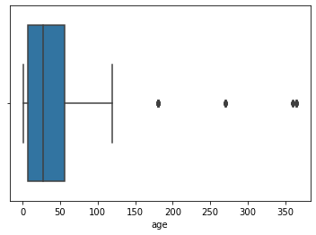

```python
# will check if there are any outliers in the distribution of Age.
sns.boxplot(x='age', data=df, orient='h')
```

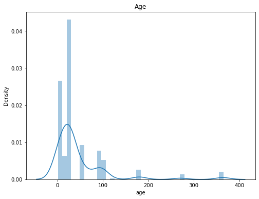

```python
plt.figure(figsize=(8,6))
sns.distplot(df['age']).set_title('Age', color='black')
```

### will calculate for the Ash.

```python
# the following code of line prints the Quartiles.
Q1=df['ash'].quantile(q=0.25)
Q3=df['ash'].quantile(q=0.75)
print('1st Quartile (Q1)is:', Q1)
print('3rd Quartile (Q3)is:', Q3)
print('interquartile range (IQR) is', stats.iqr(df['ash']))
```

```
1st Quartile (Q1)is: 0.0
3rd Quartile (Q3)is: 118.3
interquartile range (IQR) is 118.3
```

```python
# The following code of line to detect the interquartile range (IQR) is the original.
AL_outliers=Q1-1.5*(Q3-Q1)
AU_outliers=Q3+1.5*(Q3-Q1)
print('Lower outlier limit in ash', AL_outliers )
print('Upper outlier limit in ash', AU_outliers)
```

```
Lower outlier limit in ash -177.45
Upper outlier limit in ash 295.75
```

```python
# The following code of lines to check the presence of the outliers with the lower & upper limits.
print('Number of the outlier in ash upper : ', df[df['ash']>295.75]['ash'].count())
print('Number of the outlier in ash Lower : ', df[df['ash']<-177.45]['ash'].count())
print('% of outlier in ash Upper: ',round(df[df['ash']>295.75]['ash'].count()*100/len(df)),'%')
print('% of outlier in ash Lower: ',round(df[df['ash']<-177.45]['ash'].count()*100/len(df)),'%')
```

```
Number of the outlier in ash upper :  0
Number of the outlier in ash Lower :  0
% of outlier in ash Upper:  0 %
% of outlier in ash Lower:  0 %
```

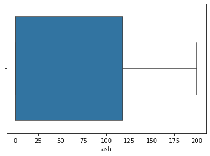

```python
# will check if there are any outliers in the distribution of Ash.
sns.boxplot(x='ash', data=df, orient='h')
```

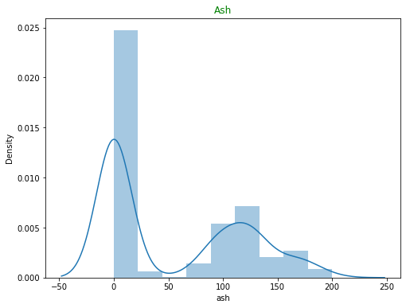

```python
plt.figure(figsize=(8,6))
sns.distplot(df['ash']).set_title('Ash', color='green')
```

## Multivariant Analysis.

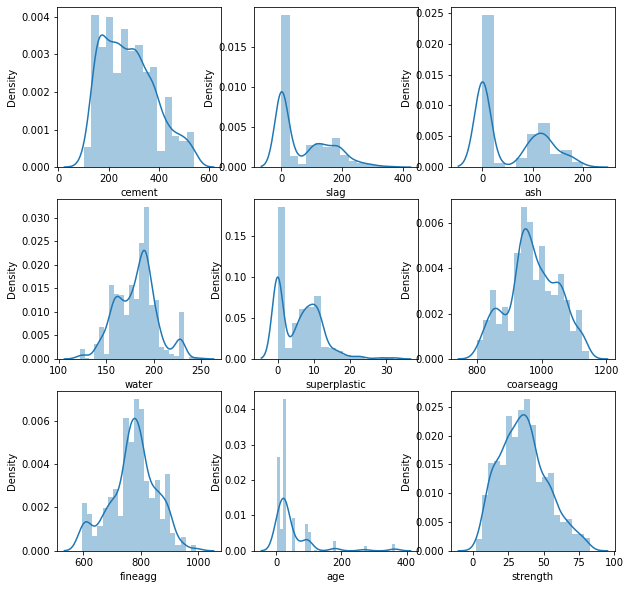

```python
# Displot
fig, ax2 = plt.subplots(3, 3, figsize=(10, 10))
sns.distplot(df['cement'], ax=ax2[0][0])
sns.distplot(df['slag'], ax=ax2[0][1])
sns.distplot(df['ash'], ax=ax2[0][2])
sns.distplot(df['water'], ax=ax2[1][0])
sns.distplot(df['superplastic'], ax=ax2[1][1])
sns.distplot(df['coarseagg'], ax=ax2[1][2])
sns.distplot(df['fineagg'], ax=ax2[2][0])
sns.distplot(df['age'], ax=ax2[2][1])
sns.distplot(df['strength'], ax=ax2[2][2])
```

# Observations.

```python
print('Outliers in cement: ',df[((df.cement - df.cement.mean()) / df.cement.std()).abs() >3]['cement'].count())
print('Outliers in slag: ',df[((df.slag - df.slag.mean()) / df.slag.std()).abs() >3]['slag'].count())
print('Outliers in ash: ',df[((df.ash - df.ash.mean()) / df.ash.std()).abs() >3]['ash'].count())
print('Outliers in water: ',df[((df.water - df.water.mean()) / df.water.std()).abs() >3]['water'].count())
print('Outliers in superplastic: ',df[((df.superplastic - df.superplastic.mean()) / df.superplastic.std()).abs() >3]['superplastic'].count())
print('Outliers in coarseagg: ',df[((df.coarseagg - df.coarseagg.mean()) / df.coarseagg.std()).abs() >3]['coarseagg'].count())
print('Outliers in fineagg: ',df[((df.fineagg - df.fineagg.mean()) / df.fineagg.std()).abs() >3]['fineagg'].count())
print('Outliers in age: ',df[((df.age - df.age.mean()) / df.age.std()).abs() >3]['age'].count())
```

```
Outliers in cement:  0
Outliers in slag:  4
Outliers in ash:  0
Outliers in water:  2
Outliers in superplastic:  10
Outliers in coarseagg:  0
Outliers in fineagg:  0
Outliers in age:  33
```

### Replacing the outliers with the median.

```python
for cols in df.columns[:-1]:
    Q1 = df[cols].quantile(0.25)
    Q3 = df[cols].quantile(0.75)
    iqr = Q3 - Q1

    low = Q1-1.5*iqr
    high = Q3+1.5*iqr
    df.loc[(df[cols]< low) | (df[cols] >high), cols] = df[cols].median()
```

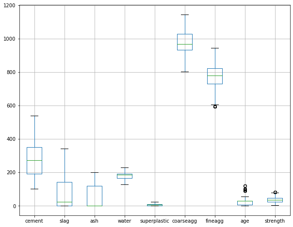

```python
df.boxplot(figsize=(10,8))
```

# Transposing index and columns.

```python
# Following line code to print the dataset columns.
df.columns
```

```
Index(['cement', 'slag', 'ash', 'water', 'superplastic', 'coarseagg',
       'fineagg', 'age', 'strength'],
      dtype='object')
```

```python
# The following line code to print the dataset unique values.
df.nunique()
```

```
cement          278
slag            184
ash             156
water           190
superplastic    109
coarseagg       284
fineagg         302
age              10
strength        845
dtype: int64
```

```python
# following code line to print categorical columns.
categorical_variables=[col for col in df.columns if df[col].nunique()<=500]
print(categorical_variables)
```

```
['cement', 'slag', 'ash', 'water', 'superplastic', 'coarseagg', 'fineagg', 'age']
```

```python
# Following code line to print continuous variables.
continuous_variables=[col for col in df.columns if df[col].nunique()]
print(continuous_variables)
```

```
['cement', 'slag', 'ash', 'water', 'superplastic', 'coarseagg', 'fineagg', 'age', 'strength']
```

```python
# Print dataset numerical variables.
num_var=list(df.select_dtypes(exclude='object').columns)
df[num_var]
```

|  | cement | slag | ash | water | superplastic | coarseagg | fineagg | age | strength |
| --- | --- | --- | --- | --- | --- | --- | --- | --- | --- |
| 0 | 141.30 | 212.00 | 0.00 | 203.50 | 0.00 | 971.80 | 748.50 | 28 | 29.89 |
| 1 | 168.90 | 42.20 | 124.30 | 158.30 | 10.80 | 1,080.80 | 796.20 | 14 | 23.51 |
| 2 | 250.00 | 0.00 | 95.70 | 187.40 | 5.50 | 956.90 | 861.20 | 28 | 29.22 |
| 3 | 266.00 | 114.00 | 0.00 | 228.00 | 0.00 | 932.00 | 670.00 | 28 | 45.85 |
| 4 | 154.80 | 183.40 | 0.00 | 193.30 | 9.10 | 1,047.40 | 696.70 | 28 | 18.29 |
| ... | ... | ... | ... | ... | ... | ... | ... | ... | ... |
| 1025 | 135.00 | 0.00 | 166.00 | 180.00 | 10.00 | 961.00 | 805.00 | 28 | 13.29 |
| 1026 | 531.30 | 0.00 | 0.00 | 141.80 | 6.40 | 852.10 | 893.70 | 3 | 41.30 |
| 1027 | 276.40 | 116.00 | 90.30 | 179.60 | 8.90 | 870.10 | 768.30 | 28 | 44.28 |
| 1028 | 342.00 | 38.00 | 0.00 | 228.00 | 0.00 | 932.00 | 670.00 | 28 | 55.06 |
| 1029 | 540.00 | 0.00 | 0.00 | 173.00 | 0.00 | 1,125.00 | 613.00 | 7 | 52.61 |

1030 rows × 9 columns

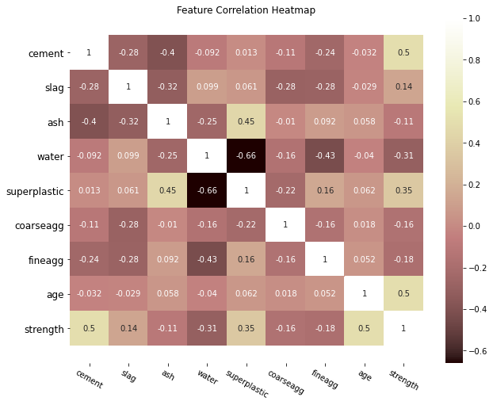

```python
# The following line of code to plot the heatmap.
fig=plt.figure(figsize=(10,8))
corr = df.corr()
sns.heatmap(corr, annot=True, cmap='pink')
b, t = plt.ylim()
plt.ylim(b+0.5, t-0.5)
fig.set_size_inches(10,8)
plt.xticks(fontsize=10,rotation=-30)
plt.yticks(fontsize=12)
plt.title('Feature Correlation Heatmap')
plt.show()
```